# Good plot Bad plot

Author

Wei Shen Lim

Published

October 14, 2026

### **Overview:**

This is an assignment to make a bad plot and a good plot using the same dataset.

### **Load Libraries**

```r
library(tidyverse)
library(here)
library(base64enc) #convert image to data URI to be embedded in Plotly plots
library(plotly)    #interactive, animated plot
library(leaflet)   #interactive HTML map
```

### **Load Data**

I am using data from the Sherwood et al. 2025 paper - [Systematics and taxonomy of *Codium* (Bryopsidales, Chlorophyta) in the Hawaiian Islands: Description of six new species](https://onlinelibrary.wiley.com/doi/full/10.1111/jpy.70091). Specifically, I’m using the [collection information of Hawaiian *Codium* specimens](https://onlinelibrary.wiley.com/action/downloadSupplement?doi=10.1111%2Fjpy.70091&file=jpy70091-sup-0016-TableS1.docx) analyzed in this study, to illustrate the collection locations of characterized specimens belonging to each clade/taxon of Hawaiian *Codium*.

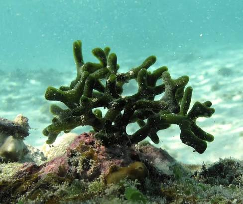

I created my own dataset from this and saved it as “collection_data.csv”. Some of the data I used from this includes:

- Taxon (species)
- Authority (taxonomic authority)
- Type (specimen type)
- Island (collection location)
- Date (collection date)
- Depth (collection depth in meters)
- Collector (specimen collectors)
- Lat (latitude of collection location)
- Long (longitude of collection location)

```r
data <- read_csv(here("GoodPlotBadPlot", "Data", "collection_data.csv"))
```

### **Bad Plot**

For my bad plot, I decided to plot an interactive, animated 3D scatter plot through Plotly to illustrate the collection locations of these characterized specimens.

#### **Load in PNMS map**

I started by loading in a map of the Papahānaumokuākea National Marine Sanctuary (PNMS) map to include in my plot.

```r
#Load in Papahānaumokuākea National Marine Sanctuary map
PNMS <- dataURI(      #convert from URL into a data URI that Plotly can display as an image
  file = "https://www.papahanaumokuakea.gov/new-images/pmnm-map-exp-1.jpg",
  mime = "image/jpeg" #specify that image is a JPEG file
)
```

#### **Plot “map”**

Then, I plotted the “map”.

```r
#Convert Depth column to a numeric type before plotting
data$Depth <- as.numeric(as.character(data$Depth))

#Create interactive, animated 3D scatter plot
plot_ly(data = data,                                  #Use original dataset
        x = ~Long,                                    #Use longitude for x-axis
        y = ~Lat,                                     #Use latitude for y-axis
        z = ~Depth,                                   #Use depth for x-axis
        frame = ~Taxon,                               #Create animation frames based on Taxon column
        text = ~Island,                               #Use location names as text labels for points
        type = "scatter3d",                           #Create 3D scatter plot
        mode = "markers+text",                        #Display both data points and text labels
        textposition = "bottom right",                #Position text labels to the bottom right of its point
        marker = list(size = 8, color = "darkgreen"), #Set marker size to 8 and color to dark green
        textfont = list(color = "darkgreen"),         #Set text color to dark green
        showlegend = FALSE) |>                        #Hide the legend from the plot
  layout(title = list(text = "Codium"), #Set plot title
         images = list(source = PNMS,      #Add PNMS map image
                       xref = "paper",     #Position image relative to plot's width
                       yref = "paper",     #Position image relative to plot's height
                       x = 1,              #Place image's right edge at the right boundary
                       y = 1,              #Place image's top edge at the top boundary
                       sizex = 0.35,       #Set image width to 45% of the plot's width
                       sizey = 0.35,       #Set image height to 45% of the plot's height
                       xanchor = "right",  #Align image using its right edge
                       yanchor = "top",    #Align image using its top edge
                       sizing = "contain", #Preserve the image's aspect ratio within its allotted size
                       opacity = 1,        #Make the image fully opaque
                       layer = "above"),   #Place the image above the plot's data traces
         paper_bgcolor = "darkblue") |> #Set background color to dark blue
           animation_opts(frame = 1000,       #Set animation frame duration to 1 second
                          transition = 1000,  #Set frame transition duration to 1 second
                          redraw = TRUE)      #Redraw the plot for each frame
```

[interactive chart not shown]

Figure 1: Collection locations of Hawaiian *Codium* species (Bad Plot)

#### **Why this is bad!**

This is a bad plot in many ways. Firstly, my intention for this plot is to show the collection locations of these specimens. Instead of plotting the points onto an actual map, I decided to use a simple scatter plot to show the overall spatial distribution of these points. While the plotted data is accurate, you cannot easily identify the exact locations of these points. I’ve attached a very small map of PMNS as a reference, so readers will have to look the points and the text associated with it that has their location name, and match it to the barely visible map.

Next, I decided to mess with the aesthetics but with reasons. I’ve set the background to be dark blue, because we are in the ocean, and the points and texts of all taxon to dark green, because *Codium* is dark green. This allows you experience what it is like to find these specimens in the field. By doing so, the data is now significantly difficult to read, and I decided not to waste time changing the color of the axes, defaulting to its dark grey color, also making it difficult for the readers to see, but you can still see it if you just zoom in. I decided to use the default axes labels from my dataset, it still accurately represents the axes, but you have to guess what the unit for depth is. I labeled the title of this plot simply as “Codium”, which is accurate but doesn’t provide adequate information, you might even miss it because it is also in dark grey. Lastly, I removed the legend for taxon and set all taxon to have the same color, so you just have to refer to the bottom label every time you switch between frames to know which specific taxon you’re looking at.

Overall, this “map” is presented in the **wrong format** (scatter plot), **misleading** (longitude and depth axis flip by default), **difficult to interpret** (3D, have to reference to small map, switched between frames per second, inadequate labels), and **plain ugly** (same dark-colored points and texts for all taxon, and dark-colored labels on a dark background). 5 observations are also missing from this plot because they do not have depth information, so this does not fully show all the data analyzed in this study.

### **Good plot**

Now we’re moving on to the good plot, using the exact same dataset. For this, I made an interactive map using Leaflet.

#### **Set Color Scale and Icon Design**

I started by assigning marker color to each taxon. I did this by creating a new column in my dataset as the markerColor argument in the Leaflet awesomeIcons() function only accepts 19 predefined color names.

```r
#Create new dataset with marker_color column to assign a marker color
data_color <- data |>
  mutate(marker_color = case_when( #Assign marker color to each species based on its name in Taxon column
    Taxon == "Codium pikoii" ~ "red",
    Taxon == "Codium cf. desultorium" ~ "darkred",
    Taxon == "Codium upohoae" ~ "lightred",
    Taxon == "Codium hakakaupilii" ~ "orange",
    Taxon == "Codium cf. hawaiiense" ~ "beige",
    Taxon == "Codium cf. intermedium" ~ "green",
    Taxon == "Codium kanepohihiae" ~ "darkgreen",
    Taxon == "Codium cf. campanulatum" ~ "lightgreen",
    Taxon == "Codium cf. mamillosum" ~ "blue",
    Taxon == "Codium taylorii" ~ "darkblue",
    Taxon == "Codium torulosum" ~ "lightblue",
    Taxon == "Codium geppiorum4" ~ "purple",
    Taxon == "Codium edule" ~ "darkpurple",
    Taxon == "Codium reediae" ~ "pink",
    Taxon == "Codium cf. arabicum" ~ "cadetblue",
    Taxon == "Codium iolekaae" ~ "lightgray",
    Taxon == "Codium saccatum" ~ "gray",
    Taxon == "Codium phasmaticum" ~ "black"
  ))
```

Next, I created customized icons for the markers, reading in the color scale that I made previously.

```r
#Create customized icons for the map markers
all_icons <- awesomeIcons(
  icon = "ion-leaf",                    #Use a leaf-shaped icon for each marker
  library = "ion",                      #Use the Ionicons icon library
  iconColor = "white",                  #Set the leaf symbol to white
  markerColor = data_color$marker_color #Assign each marker the color stored in its row's marker_color column
)
```

#### **Build base layer**

Here, I started plotting my interactive Leaflet map. This code chunk builds the first base layer, reading in the map base layer and including all data points (all taxon) as my first layer - assigned as “All species”.

```r
#Create Leaflet map and add Esri satellite imagery as the base layer
map <- leaflet() |>
  addProviderTiles(providers$Esri.WorldImagery) |>

#Add markers for all species to the map
  addAwesomeMarkers(
    data = data_color, #Use full dataset for the markers
    lng = ~Long,       #Use Long column for longitude coordinates
    lat = ~Lat,        #Use Lat column for latitude coordinates
    icon = all_icons,  #Use previously created icons with species-specific colors
    label = ~lapply(paste0("<i>", Taxon, "</i>"), #Display italicized taxon names when hovering over markers
                    htmltools::HTML),
    popup = ~paste("Taxon: <i>", Taxon, "</i>",                                 #Display specimen information when a marker is clicked
                   "<br>Authority:", Authority,                                 #Display taxonomic authority
                   ifelse(is.na(Type), "", paste0("<br>Type: ", Type)),         #Include Type only when its value is not NA
                   "<br>Location:", Island,                                     #Display the collection location
                   "<br>Collection Date:", Date,                                #Display the collection date
                   "<br>Collector:", Collector,                                 #Display the collector's name
                   ifelse(is.na(Depth), "", paste0("<br>Depth:", Depth, "m"))), #Include Depth only when its value is not NA
    clusterOptions = markerClusterOptions( #Group nearby markers into clusters
      showCoverageOnHover = TRUE,          #Show the area covered by a cluster on hover
      maxClusterRadius = 40,               #Default is 80 pixels; lower = tighter spacing
      disableClusteringAtZoom = 15),       #Turn off clustering at zoom level 15 and closer
    group = "All species") #Assign all markers to one layer
```

#### **Build remaining layers**

Here, I built the rest of my layers, separated by taxon. This allows users to subset specific taxon that they are interested in.

```r
#Get a list of unique species names from the Taxon column
species <- unique(data_color$Taxon)

#Repeat marker creation process for each individual species
for (i in species) {

  species_data <- filter(data_color, Taxon == i) #Create a subset containing only data for the current species

  species_icons <- awesomeIcons(             #Create icons using the marker colors assigned to this species
    icon = "ion-leaf",                       #Use a leaf-shaped icon
    library = "ion",                         #Use the Ionicons icon library
    iconColor = "white",                     #Set the leaf symbol to white
    markerColor = species_data$marker_color) #Assign each marker the color stored in its row's marker_color column

  #Add markers to the current species as a separate map layer
  map <- map |>
  addAwesomeMarkers(
    data = species_data,  #Use only data belonging to the current species
    lng = ~Long,          #Set marker longitude
    lat = ~Lat,           #Set marker latitude
    icon = species_icons, #Use icons created for this species
    label = ~lapply(paste0("<i>", Taxon, "</i>"), #Italicize taxon name in hover label
                    htmltools::HTML),
    popup = ~paste("Taxon: <i>", Taxon, "</i>", #Show specimen details when a marker is clicked
                   "<br>Authority:", Authority,
                   ifelse(is.na(Type), "", paste0("<br>Type: ", Type)),
                   "<br>Location:", Island,
                   "<br>Collection Date:", Date,
                   "<br>Collector:", Collector,
                   ifelse(is.na(Depth), "", paste0("<br>Depth:", Depth, "m"))),
    group = i) #Name this layer after the current species
}
```

#### **Put it all together**

Finally, I built the map with all layers combined, but with the option to toggle between layers (taxon). The default output hides all other taxon layers to reduce clutter at first glance.

```r
#Hide individual species layers initially and add a layer-selection control
map |>
  hideGroup(species) |>
  addLayersControl(
    overlayGroups = c("All species", species)) #Allow user to toggle the complete dataset or individual species
```

[interactive chart not shown]

Figure 2: Collection locations of Hawaiian *Codium* species (Good Plot)

#### **Why this is good!**

This is a good plot for the following reasons. Firstly, the intention matches the output. This clearly shows the collection locations of these specimens, with accurate markers matching their exact locations found on a map. To make this more readable, I clustered nearby markers for my first “All species” layer, allowing readers to zoom into specific clusters by clicking on them. Instead of setting a set animation to switch between taxon, readers are able to toggle between taxon themselves. Each taxon has a different marker color to clearly identify different groups when viewing all taxon, or multiple taxon based on what was selected. These colors and markers also clearly contrast the background map layer, instead of blending into it. A legend is presented in the form of the layer control function, allowing readers to view all taxon available in this dataset at once. Depth is not directly plotted onto this map to reduce complexity, instead, all relevant information are included in a popup, which readers can see when they click on specific markers. Hovering over markers also allow readers to immediately identify which taxon was collected from that specific location. In these labels, the scientific names are accurately italicized.

Overall, this map is presented in the **correct format**, **accurately presents all data**, **easy to interpret**, and **aesthetically pleasing**.